# Have federal agencies become more partisan over time?

Samiha Bhushan

University of Wisconsin-Madison  
my@email.com

Abstract

```r
# Seed for random number generation
set.seed(42)
knitr::opts_chunk$set(cache.extra = knitr::rand_seed)
```

# Research Questions

Does variation in financial agencies’ independence affect congressional success in rulemaking?

How does variation in the number of congressional coalitions affect congressional success in financial agency rulemaking?

Does either conformity or deviation from the party of the President affect congressional success?

Do members of Congress increasingly utilize partisan rhetoric over time to influence success within financial agency rulemaking? - Does variation in partisan rhetoric affect congressional success?

#Abstract (125 words) The outcomes to federal rulemaking proposals in response to congressional lobbying is integral towards understanding how government institutions work. However, federal agencies vary in level of independence, as measured by how responsive they are to public demands. Previous studies have shown that federal agency rulemaking, especially within the financial divisions, has become more independent over time, with agencies becoming less responsive to public comments. Using data from prior studies conducted by Dr. Jennifer Selin and Dr. Devin Judge-Lord, I seek to study whether this pattern can be seen within the congressional sphere — i.e. if financial federal agencies are responsive to congressmembers’ demands. I also attempt to see if there may be any change of influence for those within the same or opposing party of the President.

# Methods

I will gather data from 40 rules issued by financial agencies, including but not limited to the Consumer Financial Protection Bureau, the Treasury Department, and the Office of the Comptroller of the Currency. I focus on public comments issued by members of Congress and focus on whether their demands were ultimately fulfilled in the final rule. The research design additionally combines data from a previous study conducted by Jennifer L. Selin, who determined an estimate of the level of structural independence for several agencies during the Obama administration. My study will also include rules during the subsequent Trump administration, wherein the Senate majority switched to the Republican party. I will compare and contrast rules from both eras to determine if influence from political parties have grown over time, including determining if there is an increased presence of politicians commenting on policies. I will also use textual analysis in addition to the hand coding to see if elected officials use more partisan rhetoric over time. In this study, “partisan rhetoric” refers to an individual making positive assertions about their own party or negative assertions about the opposing party. I will also examine whether the demands of elected officials that are the same party as the President are increasingly met over those of the opposing party.

## Participants

## Material

## Procedure

## Data analysis

# Results

### Simulated Data

Does either conformity or deviation from the party of the President affect congressional success?

One measure of agency independence may be examined by studying the effects of congressmember’s party affiliation and whether it conforms with the President’s party affiliation.

We have the following data for 10 congressmembers:

`Success`: whether agencies fullfilled Congressmembers’ demands, measured between -2 and 2.

`Party`: “1” for if the party is the same for the congressmember and the President and “0” if the party is different between the congressmember and the President.

`Independence`: The estimates of agency independence, derived from Selin’s data.

`Coalitions` : sizes of coalitions that the congressmember is affiliated with.

```r
library(tidyverse)
library(tibble)
library(msm)
library(kableExtra)
congressional_success <- sample(x = c(-2, -1, 0, 1, 2), 1000, prob = c(0.1, 0.3, .1, 0.4, 0.1), replace = T)
d = tibble(rule_id = c(1:1000, rep(1001:1500, 2)),
           congress_id = sample(1:2000),
           coalitions  = c(rep(1, 1000), rep(2, 1000)),
           congressional_success = c(congressional_success, sort(congressional_success)),
           coalition_size = rtnorm(1000, mean = 5, sd= 10, lower = 1) %>% rep(2) %>% round(),
           party_affiliation = sample(x = c(0,1), 2000, replace = T, prob = c(0.7, .3)),
           independence = sample(x = c(4.1,1.643,0.174,0.218,2.269), 2000, replace = T),
           comments= c(rtnorm(1000, mean = 10000, sd = 100000, lower = 100), rep(1, 1000)) %>%
sample() %>% round() ,
           cong_support = c(rtnorm(1000, mean = 1, sd = 5, lower = 0), rep(0, 1000)) %>% sample() %>% round() )
d %>% sample_n(10) %>% dplyr::select(rule_id, congress_id, everything())
```

```
## # A tibble: 10 × 9
##    rule_id congress_id coalitions congressional_success coalition_size
##      <int>       <int>      <dbl>                 <dbl>          <dbl>
##  1    1317        1583          2                     1             14
##  2     305        1406          1                     2             34
##  3     988        1113          1                     1              2
##  4     678         683          1                     1             21
##  5     346        1970          1                     1              8
##  6     434         407          1                     1              6
##  7     918         332          1                    -1              7
##  8     941         642          1                    -1             13
##  9     289        1225          1                     1             17
## 10     185         265          1                     0             12
## # … with 4 more variables: party_affiliation <dbl>, independence <dbl>,
## #   comments <dbl>, cong_support <dbl>
```

# Hypotheses

H1: Members of Congress of the same party as the President have their demands fullfilled more often than congressmembers that are of a different politcal party. That is, the relationship between congressional success and agency independence differs by party affiliation.

H0: There is no difference in congressional success for members of Congress of the same of differing party of the President. That is, the relationship between congressional and agency independence does not differ by party affiliation.

# Linear regression

## A model

Does the model, $y_i = \beta_0 + \beta_1*party_i + \epsilon_i$, test the relationship of interest?

```r
model <- lm(congressional_success ~ party_affiliation, data = d)
m <- model %>%
  tidy(conf.int = TRUE)
m
```

```
## # A tibble: 2 × 7
##   term              estimate std.error statistic p.value conf.low conf.high
##   <chr>                <dbl>     <dbl>     <dbl>   <dbl>    <dbl>     <dbl>
## 1 (Intercept)         0.0860    0.0322     2.67  0.00770   0.0228     0.149
## 2 party_affiliation  -0.0104    0.0604    -0.172 0.864    -0.129      0.108
```

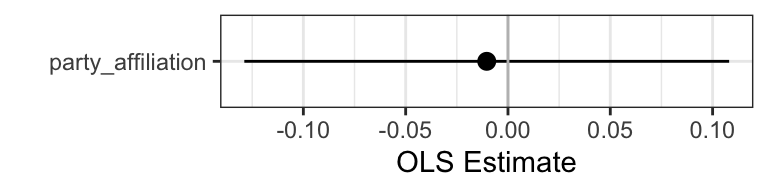

```r
ggplot(m %>% filter(term != "(Intercept)")) +
  aes(x = term,
      y = estimate,
      ymin = conf.low,
      ymax = conf.high) +
  geom_pointrange() +
  geom_hline(yintercept = 0, color = "grey") +
  coord_flip() +
  labs(x="", y="OLS Estimate")
```

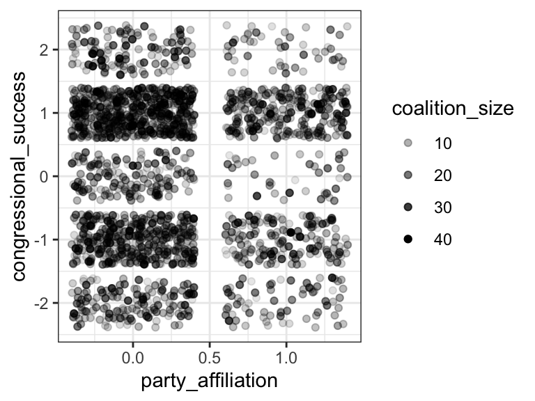

```r
# scatterplots
ggplot(d) +
  aes(x = party_affiliation, y = congressional_success) +
  geom_jitter(aes(alpha = coalition_size))
```

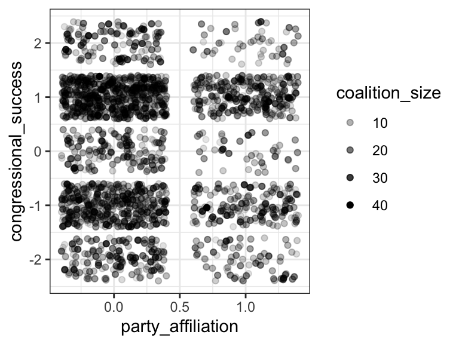

```r
p <- ggplot(d) +
  aes(x = party_affiliation, y = congressional_success) +
  geom_jitter(aes(alpha = coalition_size))
p
```

### data plot

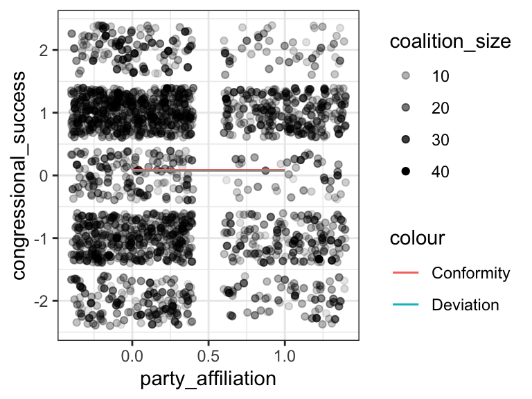

```r
# illustrating with yhat formula; more easily done with augment()
b0 <- m$estimate[1]
b1 <- m$estimate[2]
p +
  geom_line(aes(color = "Deviation", # yhat for opposition party
                y = b0 + b1*1) ) +
  geom_line(aes(color = "Conformity", # yhat for same party
                y = b0 + b1*0) )  +
  geom_ribbon(aes(ymax = b0 + b1*1,
                  ymin = b0 + b1*0), alpha = .1, color = NA)
```

t-test (compare model output to simple t-test of difference in mean `congressional success` by `party`).

```r
# tidy model output object
m
```

```
## # A tibble: 2 × 7
##   term              estimate std.error statistic p.value conf.low conf.high
##   <chr>                <dbl>     <dbl>     <dbl>   <dbl>    <dbl>     <dbl>
## 1 (Intercept)         0.0860    0.0322     2.67  0.00770   0.0228     0.149
## 2 party_affiliation  -0.0104    0.0604    -0.172 0.864    -0.129      0.108
```

```r
# t-test
t.test(congressional_success ~ party_affiliation, data = d) %>% tidy()
```

```
## # A tibble: 1 × 10
##   estimate estimate1 estimate2 statistic p.value parameter conf.low conf.high
##      <dbl>     <dbl>     <dbl>     <dbl>   <dbl>     <dbl>    <dbl>     <dbl>
## 1   0.0104    0.0860    0.0756     0.170   0.865     1018.   -0.110     0.130
## # … with 2 more variables: method <chr>, alternative <chr>
```

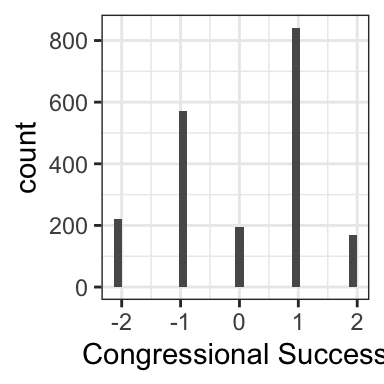

```r
ggplot(d, aes(x = congressional_success)) + geom_histogram()+ labs(x = "Congressional Success")
```

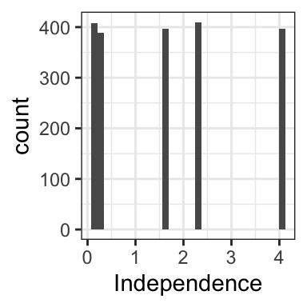

```r
ggplot(d, aes(x = independence)) + geom_histogram()+ labs(x = "Independence")
```

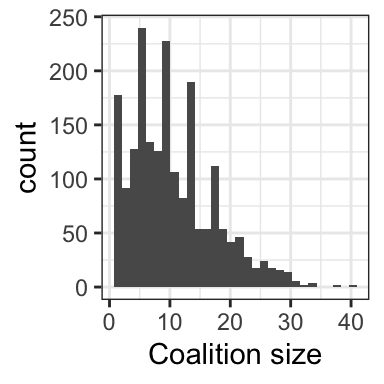

```r
ggplot(d, aes(x = coalition_size)) + geom_histogram()+ labs(x = "Coalition size")
```

### Multiple linear regression

$y_i = \beta_0 + \beta_1*party_i + \beta_2*independence_i + \epsilon_i$

```r
model_1 <- lm(congressional_success ~ independence + party_affiliation, data = d)
      augment()
```

```
## # A tibble: 0 × 0
```

```r
summary(model_1)
```

```
##
## Call:
## lm(formula = congressional_success ~ independence + party_affiliation,
##     data = d)
##
## Residuals:
##     Min      1Q  Median      3Q     Max
## -2.1305 -1.0849  0.8695  0.9286  1.9516
##
## Coefficients:
##                   Estimate Std. Error t value Pr(>|t|)
## (Intercept)        0.05437    0.04534   1.199    0.231
## independence       0.01857    0.01876   0.990    0.322
## party_affiliation -0.00919    0.06042  -0.152    0.879
##
## Residual standard error: 1.219 on 1997 degrees of freedom
## Multiple R-squared:  0.0005056,  Adjusted R-squared:  -0.0004954
## F-statistic: 0.5051 on 2 and 1997 DF,  p-value: 0.6035
```

```r
m1 <- model_1 %>%
  tidy(conf.int = TRUE)
m1
```

```
## # A tibble: 3 × 7
##   term              estimate std.error statistic p.value conf.low conf.high
##   <chr>                <dbl>     <dbl>     <dbl>   <dbl>    <dbl>     <dbl>
## 1 (Intercept)        0.0544     0.0453     1.20    0.231  -0.0345    0.143
## 2 independence       0.0186     0.0188     0.990   0.322  -0.0182    0.0554
## 3 party_affiliation -0.00919    0.0604    -0.152   0.879  -0.128     0.109
```

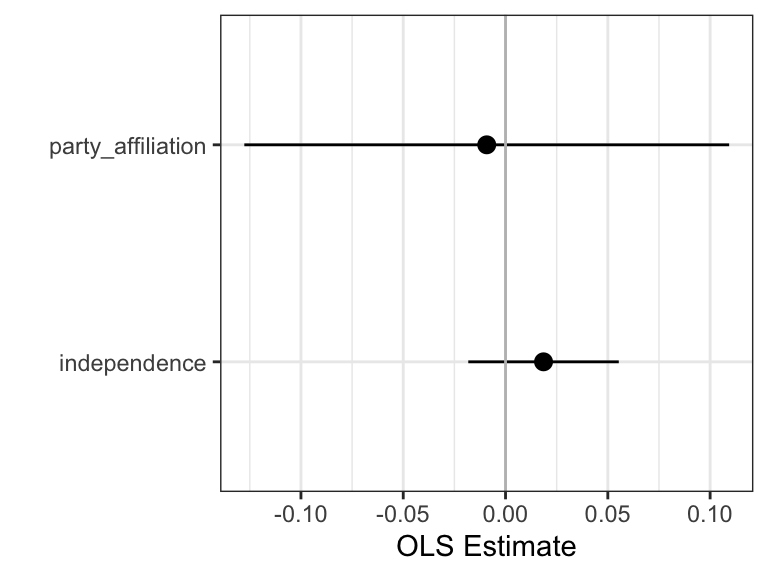

```r
ggplot(m1 %>% filter(term != "(Intercept)")) +
  aes(x = term,
      y = estimate,
      ymin = conf.low,
      ymax = conf.high) +
  geom_pointrange() +
  geom_hline(yintercept = 0, color = "grey") +
  coord_flip() +
  labs(x="", y="OLS Estimate")
```

### Let’s plot the results against our data!

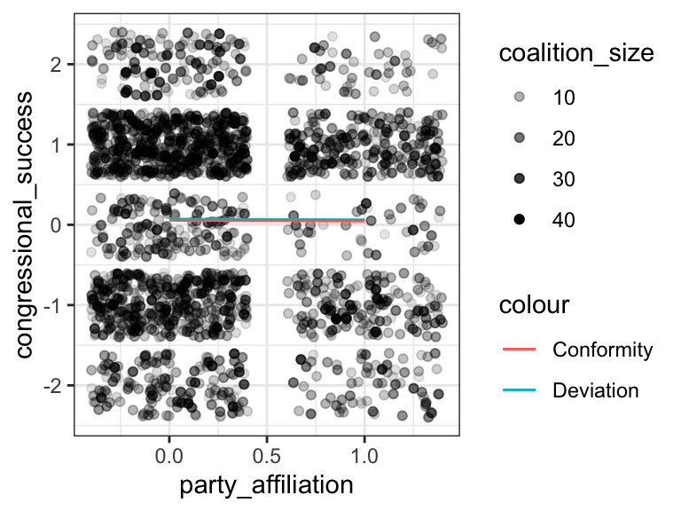

```r
# illustrating with yhat formula; more easily done with augment()
b0 <- m1$estimate[1]
b1 <- m1$estimate[2]
b2 <- m1$estimate[3]
p +
  geom_line(aes(color = "Deviation", # yhat for opposition party
                y = b0 + b1*1 + b2*party_affiliation) ) +
  geom_line(aes(color = "Conformity", # yhat for same party
                y = b0 + b1*0 + b2*party_affiliation) )  +
  geom_ribbon(aes(ymax = b0 + b1*1+ b2*party_affiliation,
                  ymin = b0 + b1*0+ b2*party_affiliation), alpha = .1, color = NA)
```

### Fit

Let’s also plot the residuals. Aside from interpretation, we want to know where our model is a better or worse fit with the data, especially if residuals seem to vary systematically over the range of our data.

`augment` computes tidy residuals, among other cool things.

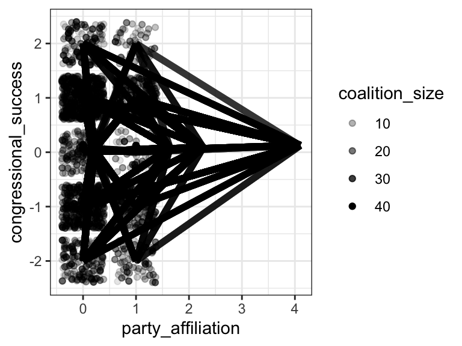

```r
m1 <- augment(model_1)
p +
  geom_line(aes(y = m1$.fitted)) + # with .fitted from augment()
  geom_point(aes(y = m1$.fitted), shape = 1, alpha = .2) + # with .fitted from augment()
  geom_segment(aes(xend = independence, yend = m1$.fitted ), alpha = .2, size = 2)
```

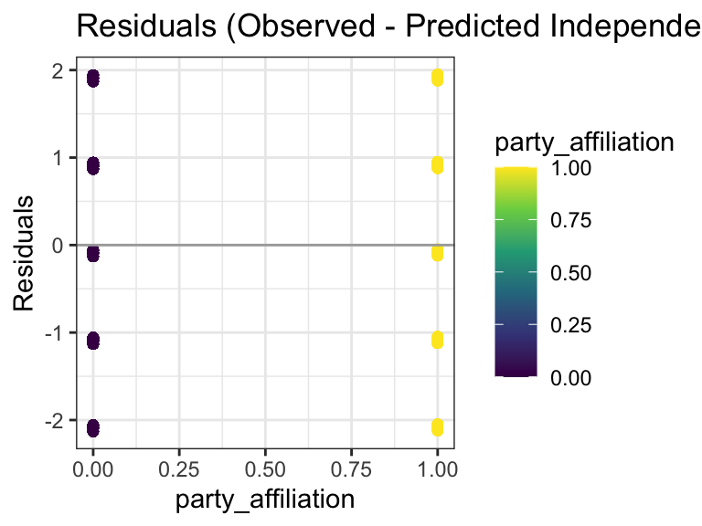

```r
ggplot(m1) +
  aes(y = .resid, x = party_affiliation) +
  geom_point(aes(color = party_affiliation)) +
  scale_color_viridis_c() +
  ## to show how risiduals are the distance between an
  ## observation and the regression line:
  geom_hline(yintercept = 0, color = "dark grey") +
  geom_text(x= mean(m1$independence), y = 0,
            label = "Regression line") +
  #geom_col(aes(fill = party_affiliation), alpha = .2, position ="identity") +
  ## + labels:
  labs(title = "Residuals (Observed - Predicted Independence)",
       y = "Residuals")
```

### AIC and BIC

```r
glance(model_1)
```

```
## # A tibble: 1 × 12
##   r.squared adj.r.squared sigma statistic p.value    df logLik   AIC   BIC
##       <dbl>         <dbl> <dbl>     <dbl>   <dbl> <dbl>  <dbl> <dbl> <dbl>
## 1  0.000506     -0.000495  1.22     0.505   0.604     2 -3232. 6472. 6495.
## # … with 3 more variables: deviance <dbl>, df.residual <int>, nobs <int>
```

### Simulated Results

```r
#FIXME move this into another script updating the comment data from google sheet, so you don't need to ping google sheets every time you knit
#comments_sheet <- read_sheet("https://docs.google.com/spreadsheets/d/1HBjG32qWVdf9YxfGPEJhNmSw65Z9XzPhHdDbLnc3mYc/edit?usp=sharing")
comments <- gsheet2tbl("https://docs.google.com/spreadsheets/d/1HBjG32qWVdf9YxfGPEJhNmSw65Z9XzPhHdDbLnc3mYc/edit?usp=sharing")

load(here("data/members.Rdata"))

agency_data <- read_excel(here("data/federal_agencies_estimate.xlsx"))
```

```r
#FIXME
members %<>%
  mutate(nominate_pres = case_when(
  congress < 111 ~ 0.693,                  #bush pres score
  congress >= 111 & congress <= 115 ~ -0.358,  #obama pres score
  congress > 115 & congress <117 ~ 0.403,      #trump pres score
  congress > 117 ~ -0.320))        #biden pres score

# LOOK AT THIS:
members %>%
  distinct(congress, nominate_pres) %>%
  arrange(congress)
```

```
## # A tibble: 12 × 2
##    congress nominate_pres
##       <int>         <dbl>
##  1      105         0.693
##  2      106         0.693
##  3      107         0.693
##  4      108         0.693
##  5      109         0.693
##  6      110         0.693
##  7      111        -0.358
##  8      112        -0.358
##  9      113        -0.358
## 10      114        -0.358
## 11      115        -0.358
## 12      116         0.403
```

```r
# Make ideological distance from president variable
members %<>% mutate(
nominate_diff = nominate.dim1-nominate_pres)

# subset comments to those from an icpsr-matched member of Congress
comments1 <- comments %>% drop_na(icpsr)

# select variables we want from members
members_selected <- members %>% select(icpsr, chamber, congress, nominate.dim1, nominate_pres, nominate_diff, party_name)

comments1 %<>% left_join(members_selected)

# Create agency variable from id
comments1 %<>% mutate(Agency = str_remove(id, "-.*") )

# Inspect agencies
unique(comments1$Agency)
```

```
##  [1] "ACF"    "AID"    "AMS"    "APHIS"  "BLM"    "BOEM"   "BSEE"   "CCC"
##  [9] "CDC"    "CEQ"    "CFPB"   "COE"    "CPSC"   "DARS"   "DEA"    "DOE"
## [17] "DOJ"    "DOL"    "DOS"    "DOT"    "EBSA"   "ED"     "EEOC"   "EERE"
## [25] "EOIR"   "ESA"    "ETA"    "FAA"    "FAR"    "FHWA"   "FINCEN" "FISCAL"
## [33] "FMCSA"  "FNS"    NA       "FRA"    "FSA"    "FSIS"   "FSOC"   "FTA"
## [41] "FTC"    "FWS"    "GIPSA"  "GSA"    "HHS"    "HRSA"   "IRS"    "ITA"
## [49] "LMSO"   "MARAD"  "MMS"    "MSHA"   "NHTSA"  "NIGC"   "NIH"    "NLRB"
## [57] "NOAA"   "NPS"    "NRC"    "NTIA"   "OCC"    "OFCCP"  "OFPP"   "OMB"
## [65] "OPM"    "OSHA"   "OSM"    "OTS"    "PHMSA"  "PTO"    "RBS"    "RITA"
## [73] "RUS"    "SBA"    "SSA"    "TREAS"  "TSA"    "TTB"    "USBC"   "USC"
## [81] "USCG"   "USDA"   "USTR"   "VA"     "WCPO"   "WHD"
```

```r
# Join in agency independence scores
comments1 %<>% left_join(agency_data, by = "Agency", copy = FALSE)

# Subset to agencies for this study
comments2 <- comments1 %>% filter(!is.na(Estimate))

# inspect agencies
# unique(comments2$Agency)

comments2 %>%
  select(congress, bioname, icpsr, party_name, nominate.dim1, nominate_pres, nominate_diff, Agency, Estimate)
```

```
## # A tibble: 370 × 9
##    congress bioname   icpsr party_name nominate.dim1 nominate_pres nominate_diff
##       <dbl> <chr>     <dbl> <chr>              <dbl>         <dbl>         <dbl>
##  1      112 MALONEY,… 29379 Democrati…        -0.387        -0.358      -0.0290
##  2      112 McCASKIL… 40701 Democrati…        -0.143        -0.358       0.215
##  3      112 HEINRICH… 20930 Democrati…        -0.325        -0.358       0.0330
##  4      113 MENENDEZ… 29373 Democrati…        -0.365        -0.358      -0.00700
##  5      112 GRAVES, … 20124 Republica…         0.442        -0.358       0.8
##  6      113 STIVERS,… 21163 Republica…         0.299        -0.358       0.657
##  7      113 PERLMUTT… 20705 Democrati…        -0.282        -0.358       0.076
##  8      112 HINOJOSA… 29763 Democrati…        -0.34         -0.358       0.0180
##  9      113 BOXER, B… 15011 Democrati…        -0.45         -0.358      -0.092
## 10      113 WARREN, … 41301 Democrati…        -0.77         -0.358      -0.412
## # … with 360 more rows, and 2 more variables: Agency <chr>, Estimate <dbl>
```

## Real data model

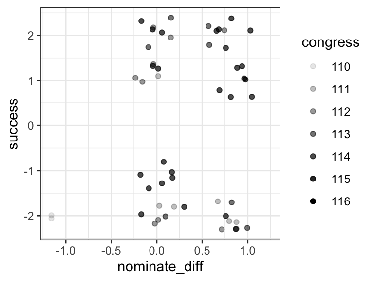

```r
# scatterplots
ggplot(comments2) +
  aes(x = nominate_diff, y = success) +
  geom_jitter(aes(alpha = congress))
```

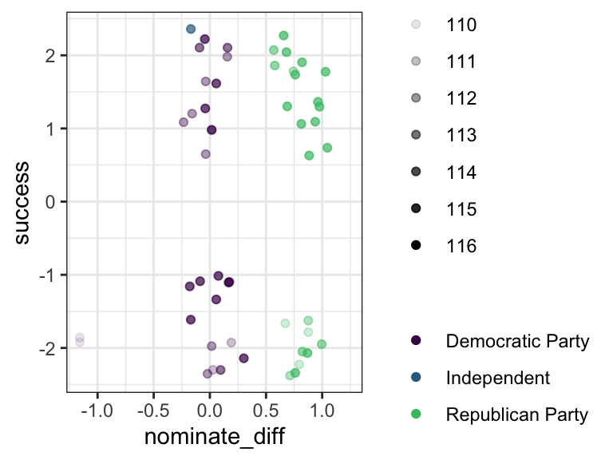

```r
# add color by party_name, and save plot as p for future use
p1 <- ggplot(comments2) +
  aes(x = nominate_diff, y = success, color = party_name) +
  geom_jitter(aes(alpha = congress)) + scale_color_discrete()

#remove legend title
p <- p1 + labs(color = NULL)
p
```

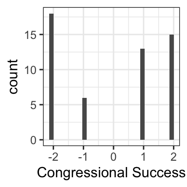

```r
ggplot(comments2, aes(x = success)) + geom_histogram()+ labs(x = "Congressional Success")
```

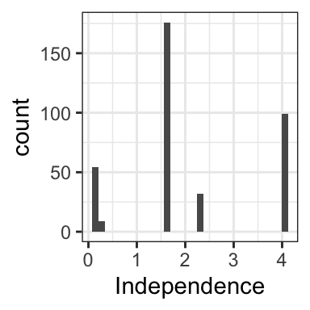

```r
ggplot(comments2, aes(x = Estimate)) + geom_histogram()+ labs(x = "Independence")
```

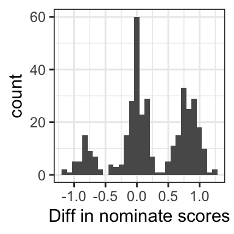

```r
ggplot(comments2, aes(x = nominate_diff)) + geom_histogram()+ labs(x = "Diff in nominate scores")
```

### Model 1

$y_i = \beta_0 + \beta_1*nominate_i + \epsilon_i$

$y_i$ is the extent to which a congressmember’s demands are fullfilled by a federal agency, from a range of -2 (agency fulfilled the opposite of their asks) to 2 (agency completely fullfilled their asks) for all three models.

$\beta_0$ references the level of success a congressmember experiences given that their nominate score is 0 (i.e. have the same nominate score as the President). $\beta_1$ references the level of success changed given a unit increase in a congressmember’s ideological distance from the President.

H0: $\beta_1$=0 Ideological distance of congressmembers from the President is not associated with success in agencies fullfilling their demands.

H1: $\beta_1$≠0 Ideological distance of congressmembers from the President is associated with success in agencies fullfilling their demands.

```r
#creating 3 models using model summary
#FIX "Estimate" var not showing up
# models <- list()
# models[['model_nom']] <- lm(success ~ nominate_diff, data = comments2, y= TRUE, x=TRUE)
# models[['model_mul']] <- lm(success ~ nominate_diff + Estimate, data = comments2)
# models[['model_int']] <- lm(success ~ nominate_diff*Estimate, data = comments2)
#
# msummary(models)
```

```r
#model 1 summary using msummary()
model_nom <- lm(success ~ nominate_diff, data = comments2, y= TRUE, x=TRUE)
      augment()
```

```
## # A tibble: 0 × 0
```

```r
msummary(model_nom)
```

|  | Model 1 |
| --- | --- |
| (Intercept) | −0.130 |
|  | (0.286) |
| nominate_diff | 0.445 |
|  | (0.467) |
| Num.Obs. | 52 |
| R2 | 0.018 |
| R2 Adj. | −0.002 |
| AIC | 208.1 |
| BIC | 213.9 |
| Log.Lik. | −101.032 |
| F | 0.906 |

```r
m_nom <- msummary(model_nom, statistic = c("p-value= {p.value}", "confidence-int" = {"conf.int"}), conf_level = .95)
m_nom
```

|  | Model 1 |
| --- | --- |
| (Intercept) | −0.130 |
|  | p-value= 0.651 |
|  | [−0.704, 0.444] |
| nominate_diff | 0.445 |
|  | p-value= 0.346 |
|  | [−0.494, 1.383] |
| Num.Obs. | 52 |
| R2 | 0.018 |
| R2 Adj. | −0.002 |
| AIC | 208.1 |
| BIC | 213.9 |
| Log.Lik. | −101.032 |
| F | 0.906 |

```r
msummary(model_nom)
```

|  | Model 1 |
| --- | --- |
| (Intercept) | −0.130 |
|  | (0.286) |
| nominate_diff | 0.445 |
|  | (0.467) |
| Num.Obs. | 52 |
| R2 | 0.018 |
| R2 Adj. | −0.002 |
| AIC | 208.1 |
| BIC | 213.9 |
| Log.Lik. | −101.032 |
| F | 0.906 |

```r
#table summary using tidy
tidy_m_nom <- model_nom %>%
  tidy(conf.int = TRUE)

tidy_m_nom
```

```
## # A tibble: 2 × 7
##   term          estimate std.error statistic p.value conf.low conf.high
##   <chr>            <dbl>     <dbl>     <dbl>   <dbl>    <dbl>     <dbl>
## 1 (Intercept)     -0.130     0.286    -0.455   0.651   -0.704     0.444
## 2 nominate_diff    0.445     0.467     0.952   0.346   -0.494     1.38
```

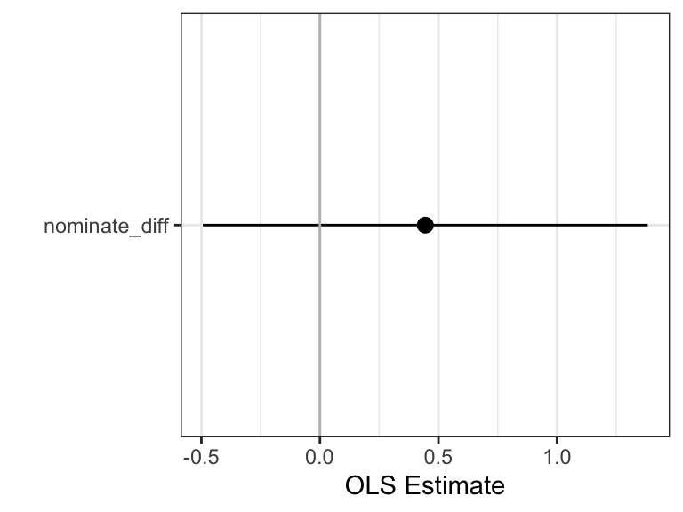

```r
#created graph using tidy not msummary()
ggplot(tidy_m_nom %>% filter(term != "(Intercept)")) +
  aes(x = term,
      y = estimate,
      ymin = conf.low,
      ymax = conf.high) +
  geom_pointrange() +
  geom_hline(yintercept = 0, color = "grey") +
  coord_flip() +
  labs(x="", y="OLS Estimate")
```

#### Model 1: Plotting Results into Data

```r
b0 <- tidy_m_nom$estimate[1]
b1 <- tidy_m_nom$estimate[2]

augment_m_nom <- augment(model_nom)
augment_m_nom
```

```
## # A tibble: 52 × 9
##    .rownames success nominate_diff  .fitted .resid   .hat .sigma .cooksd
##    <chr>       <dbl>         <dbl>    <dbl>  <dbl>  <dbl>  <dbl>   <dbl>
##  1 9               2        -0.092 -0.171    2.17  0.0327   1.71 0.0277
##  2 12             -2        -0.17  -0.206   -1.79  0.0380   1.72 0.0223
##  3 13             -2         0.302  0.00427 -2.00  0.0193   1.72 0.0136
##  4 14             -2         0.869  0.256   -2.26  0.0401   1.71 0.0374
##  5 15              2         1.03   0.328    1.67  0.0547   1.72 0.0288
##  6 16             -2         0.76   0.208   -2.21  0.0325   1.71 0.0285
##  7 17              2         0.76   0.208    1.79  0.0325   1.72 0.0188
##  8 18              2         0.057 -0.105    2.10  0.0249   1.71 0.0196
##  9 19              2         0.657  0.162    1.84  0.0268   1.72 0.0161
## 10 44             -1        -0.087 -0.169   -0.831 0.0324   1.74 0.00403
## # … with 42 more rows, and 1 more variable: .std.resid <dbl>
```

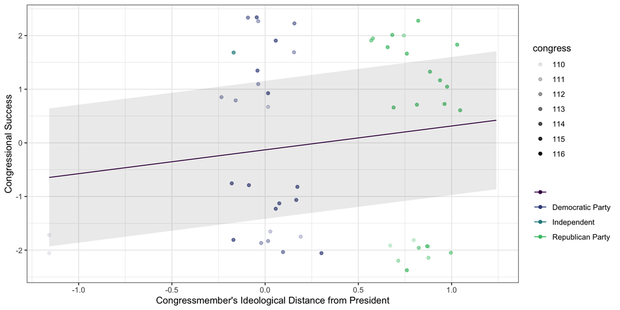

```r
#graph separated by party
p +
  geom_line(aes(color = "",
                y = b0 + b1*nominate_diff)) +
  geom_ribbon(aes(ymax = b0 + b1*nominate_diff + 1.96*0.656,
                  ymin = b0 + b1*nominate_diff - 1.96*0.656), alpha = .1, color = NA) +
  labs(y = "Congressional Success", x = "Congressmember's Ideological Distance from President")
```

```r
#remove nominate diff legend color
#make nominate_diff absolute value
#are comments from the obama administration? how many trump?
#facet by president


#t-test
model_nom
```

```
##
## Call:
## lm(formula = success ~ nominate_diff, data = comments2, x = TRUE,
##     y = TRUE)
##
## Coefficients:
##   (Intercept)  nominate_diff
##       -0.1300         0.4445
```

```r
t.test(comments2$success, comments2$nominate_diff, data = comments2) %>% tidy()
```

```
## # A tibble: 1 × 10
##   estimate estimate1 estimate2 statistic p.value parameter conf.low conf.high
##      <dbl>     <dbl>     <dbl>     <dbl>   <dbl>     <dbl>    <dbl>     <dbl>
## 1   -0.209    0.0192     0.229    -0.871   0.388      52.6   -0.692     0.273
## # … with 2 more variables: method <chr>, alternative <chr>
```

#### Model 1: Plotting Residuals

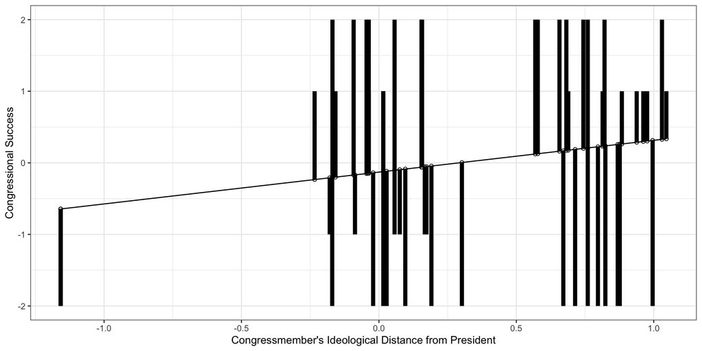

```r
augment_m_nom %>%
  ggplot() +
  aes(x = nominate_diff, y = success) +
  geom_line(aes(y = augment_m_nom$.fitted)) + # with .fitted from augment()
  geom_point(aes(y = augment_m_nom$.fitted), shape = 1, alpha = 1) + # with .fitted from augment()
  geom_segment(aes(xend = nominate_diff, yend = augment_m_nom$.fitted), alpha = 1, size = 2) +
  labs(y = "Congressional Success", x = "Congressmember's Ideological Distance from President")
```

```r
#adding residuals color
```

#### Model 2

$y_i = \beta_0 + \beta_1*nominate_i + \beta_2*independence_i + \epsilon_i$

H0: $\beta_1$=0 and $\beta_2$=0

Ideological distance of congressmembers from the President is not associated with success in agencies fullfilling their demands.

H1: $\beta_1$≠0 or $\beta_2$≠0

A congressmembers’ nominate score and/or a federal agency levels of independence have an affect on the level of success in fullfilling a congressmembers’ demands.

```r
#creating table with msummary()
model_mul <- lm(success ~ nominate_diff + Estimate, data = comments2)
model_mul
```

```
##
## Call:
## lm(formula = success ~ nominate_diff + Estimate, data = comments2)
##
## Coefficients:
##   (Intercept)  nominate_diff       Estimate
##      -0.25005        0.39233        0.06928
```

```r
m_mul <- msummary(model_mul, statistic = c("p-value= {p.value}", "confidence-int" = {"conf.int"}), conf_level = .95)
m_mul
```

|  | Model 1 |
| --- | --- |
| (Intercept) | −0.250 |
|  | p-value= 0.491 |
|  | [−0.974, 0.474] |
| nominate_diff | 0.392 |
|  | p-value= 0.417 |
|  | [−0.572, 1.356] |
| Estimate | 0.069 |
|  | p-value= 0.583 |
|  | [−0.183, 0.321] |
| Num.Obs. | 52 |
| R2 | 0.024 |
| R2 Adj. | −0.016 |
| AIC | 209.7 |
| BIC | 217.5 |
| Log.Lik. | −100.870 |
| F | 0.599 |

```r
#creating table using tidy
tidy_m_mul <- model_mul %>%
  tidy(conf.int = TRUE)

#cov(comments2$Estimate,comments2$nominate_diff)
```

For every 1 unit increase in nominate scores of congressmembers, congressional success increases by 0.392 points in federal rulemaking. The p-value is 0.417, since this is greater than 0.05, we fail to reject the null hypothesis that nominate scores or levels of agency independence do not affect congressional success. For every 1 unit increase in independence estimates of federal financial agencies, congressional success increases by 0.0693 points in federal rulemaking. The p-value is 0.583, since this is greater than 0.05, we fail to reject the null hypothesis that nominate scores or levels of agency independence do not affect congressional success.

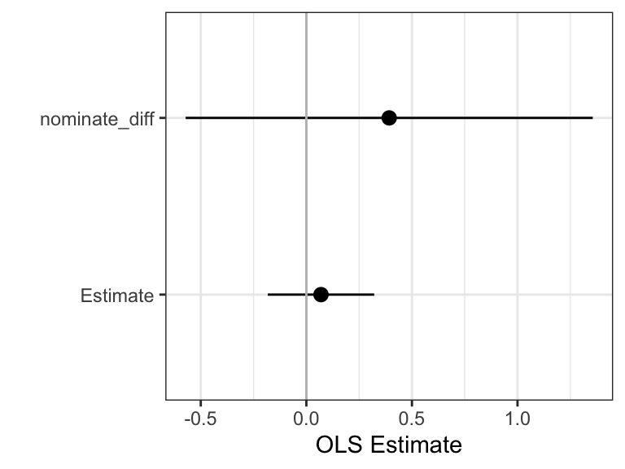

```r
#needed tidy table for ggplot
ggplot(tidy_m_mul %>% filter(term != "(Intercept)")) +
  aes(x = term,
      y = estimate,
      ymin = conf.low,
      ymax = conf.high) +
  geom_pointrange() +
  geom_hline(yintercept = 0, color = "grey") +
  coord_flip() +
  labs(x="", y="OLS Estimate")
```

### Model 2: Plotting Results

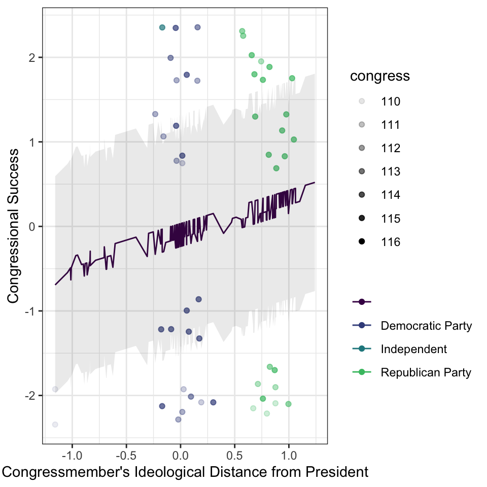

```r
b0 <- tidy_m_mul$estimate[1]
b1 <- tidy_m_mul$estimate[2]
b2 <- tidy_m_mul$estimate[3]

#results by party name
p +
  geom_line(aes(color = "",
                y = b0 + b1*nominate_diff + b2*Estimate) ) +
  geom_ribbon(aes(ymax = b0 + b1*nominate_diff+ b2*Estimate + 1.96*0.656,
                  ymin = b0 + b1*nominate_diff+ b2*Estimate - 1.96*0.656), alpha = .1, color = NA) +
  labs(y = "Congressional Success", x = "Congressmember's Ideological Distance from President")
```

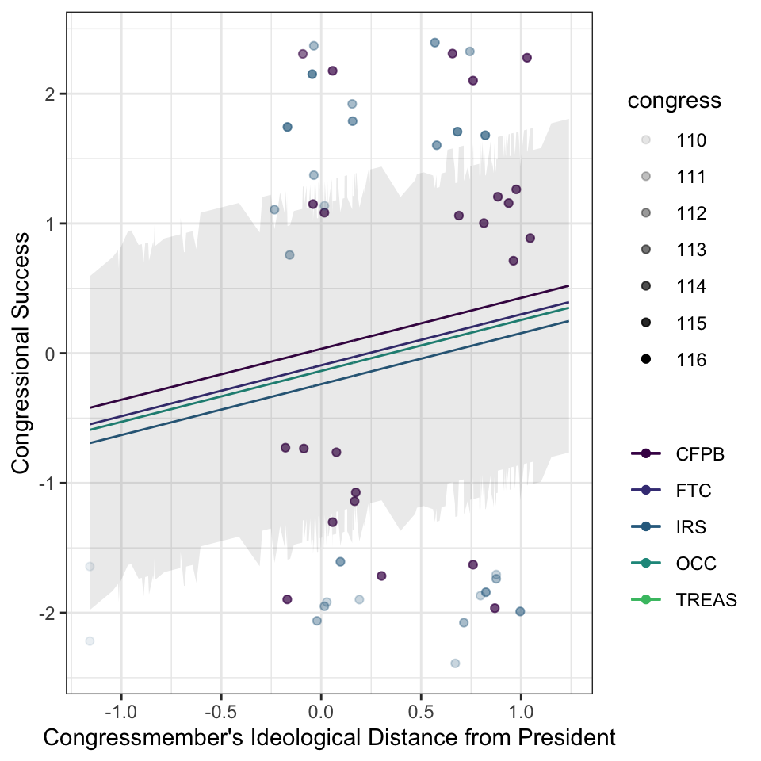

```r
# add color by agency
p2 <- ggplot(comments2) +
  aes(x = nominate_diff, y = success, color = Agency) +
  geom_jitter(aes(alpha = congress)) + scale_color_discrete()

#remove legend title
p4 <- p2 + labs(color = NULL)

#results by agency

p4 +
  geom_line(aes(color = "CFPB",
                y = b0 + b1*nominate_diff + b2*4.1) ) +
  geom_line(aes(color = "OCC",
                y = b0 + b1*nominate_diff + b2*1.643) )  +
  geom_line(aes(color = "IRS",
                y = b0 + b1*nominate_diff + b2*0.174) )  +
  geom_line(aes(color = "FTC",
                y = b0 + b1*nominate_diff + b2*2.269) ) +
  geom_ribbon(aes(ymax = b0 + b1*nominate_diff+ b2*Estimate + 1.96*0.656,
                  ymin = b0 + b1*nominate_diff+ b2*Estimate - 1.96*0.656), alpha = .1, color = NA) +
    labs(y = "Congressional Success", x = "Congressmember's Ideological Distance from President")
```

### Model 2: Interpretation

```r
#.fitted() returning aes argument
p +
  geom_line(aes(y = aug_mod_mul$.fitted)) +
  scale_x_continuous(limits = c(-40, max(comments2$nominate_diff))) +
  scale_y_continuous(limits = c(b0-3, max(comments2$success))) +
  #geom_hline(yintercept =  b0) +
  geom_label(aes(color = "Party Name"), x = 0, y = b0 + b1, label = expression(beta[0]+beta[1]*1), hjust = 0, vjust = 0,show.legend = FALSE, check_overlap = T)+
    geom_label(aes(color = "Party Name"), x = 0, y = b0 + b1, label = round(b0 + b1,1), hjust = 1,  color = "black",  show.legend = FALSE, check_overlap = T)+
  geom_point(aes(color = "Party Name"), x = 0, y = b0 + b1, shape = 1)
```

[output not shown]

### Model 2: Fit and Plotting Residuals

```r
#creating fit graph
aug_mod_mul <- augment(model_mul)
aug_mod_mul
```

```
## # A tibble: 52 × 10
##    .rownames success nominate_diff Estimate   .fitted .resid   .hat .sigma
##    <chr>       <dbl>         <dbl>    <dbl>     <dbl>  <dbl>  <dbl>  <dbl>
##  1 9               2        -0.092      4.1 -0.00209    2.00 0.0637   1.73
##  2 12             -2        -0.17       4.1 -0.0327    -1.97 0.0705   1.73
##  3 13             -2         0.302      4.1  0.152     -2.15 0.0432   1.72
##  4 14             -2         0.869      4.1  0.375     -2.37 0.0555   1.72
##  5 15              2         1.03       4.1  0.438      1.56 0.0679   1.74
##  6 16             -2         0.76       4.1  0.332     -2.33 0.0493   1.72
##  7 17              2         0.76       4.1  0.332      1.67 0.0493   1.73
##  8 18              2         0.057      4.1  0.0564     1.94 0.0531   1.73
##  9 19              2         0.657      4.1  0.292      1.71 0.0451   1.73
## 10 44             -1        -0.087      4.1 -0.000124  -1.00 0.0633   1.75
## # … with 42 more rows, and 2 more variables: .cooksd <dbl>, .std.resid <dbl>
```

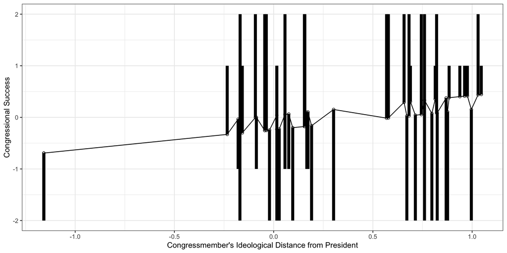

```r
aug_mod_mul %>%
  ggplot() +
  aes(x = nominate_diff, y = success) +
  geom_line(aes(y = aug_mod_mul$.fitted)) + # with .fitted from augment()
  geom_point(aes(y = aug_mod_mul$.fitted), shape = 1, alpha = 1) + # with .fitted from augment()
  geom_segment(aes(xend = nominate_diff, yend = aug_mod_mul$.fitted), alpha = 1, size = 2) +
  labs(y = "Congressional Success", x = "Congressmember's Ideological Distance from President")
```

```r
#adding residuals color
```

### Model 3

$y_i = \beta_0 + \beta_1*nominate_i + \beta_2*independence_i + \beta_3*nominate_iXindependence_i + \epsilon_i$

H0: $\beta_1$=0 and $\beta_2$=0 and $\beta_3$=0 A congressmembers’ nominate score and a federal agency levels of independence have no affect on the level of success in fullfilling a congressmembers’ demands.

H1: $\beta_1$≠0 or $\beta_2$≠0 or $\beta_3$≠0 A congressmembers’ nominate score and/or a federal agency levels of independence have an affect on the level of success in fullfilling a congressmembers’ demands.

```r
model_int <- lm(success ~ nominate_diff*Estimate, data = comments2)

#table with msummary()
m_int <- msummary(model_int, statistic = c("p-value= {p.value}", "confidence-int" = {"conf.int"}), conf_level = .95)
m_int
```

|  | Model 1 |
| --- | --- |
| (Intercept) | −0.136 |
|  | p-value= 0.718 |
|  | [−0.888, 0.616] |
| nominate_diff | −0.052 |
|  | p-value= 0.933 |
|  | [−1.308, 1.203] |
| Estimate | −0.036 |
|  | p-value= 0.821 |
|  | [−0.351, 0.280] |
| nominate_diff × Estimate | 0.282 |
|  | p-value= 0.273 |
|  | [−0.229, 0.793] |
| Num.Obs. | 52 |
| R2 | 0.048 |
| R2 Adj. | −0.011 |
| AIC | 210.4 |
| BIC | 220.2 |
| Log.Lik. | −100.213 |
| F | 0.811 |

```r
#table with tidy
tidy_m_int <- model_int %>%
  tidy(conf.int = TRUE)
```

Holding federal independence estimates at 0 points, for every 1 unit increase in nominate scores of congressmembers, congressional success decreases by 0.0525 points in federal rulemaking. The p-value is 0.933, since this is greater than 0.05, we fail to reject the null hypothesis that nominate scores or levels of agency independence do not affect congressional success. Also, for every 1 unit increase in nominate scores, success changes by -0.0525 + 0.282 ⋅ Estimate. Since the p-value is 0.273>0.05, we fail to reject the null that success changes due to nominate scores dependant on independence estimates.

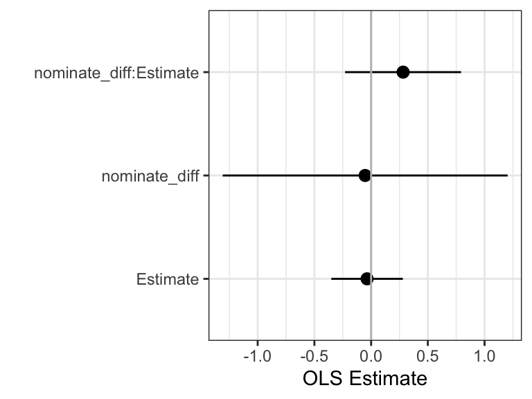

```r
ggplot(tidy_m_int %>% filter(term != "(Intercept)")) +
  aes(x = term,
      y = estimate,
      ymin = conf.low,
      ymax = conf.high) +
  geom_pointrange() +
  geom_hline(yintercept = 0, color = "grey") +
  coord_flip() +
  labs(x="", y="OLS Estimate")
```

```r
model_2 <- lm(congressional_success ~ nominate_diff, data = comments2)

m2 <- augment(model_2)


ggplot(d) +
  aes(x =  nominate_diff, y = congressional_success) +
  geom_point() + scale_color_discrete() +
  geom_line(aes(y = m2$.fitted)) + # with .fitted from augment()
  geom_point(aes(y = m2$.fitted), shape = 1, alpha = .2) + # with .fitted from augment()
    geom_segment(aes(xend = nominate_diff, yend = m2$.fitted ), alpha = .2, size = 2)
```

[output not shown]